# A quantile regression approach to define optimal ecological niche (habitat suitability) of cockle populations (*Cerastoderma edule*)

Melting Potes

Amélie Lehuen<sup>a</sup>*, Chloé Dancie<sup>b</sup>, Florent Grasso<sup>c</sup>, Francis Orvain<sup>a</sup>

Author

Amélie Lehuen

Published

August 12, 2024

<sup>a</sup> Biologie des Organismes et Ecosystèmes Aquatiques (BOREA), UMR8067, Museum National d’Histoire Naturelle (MNHN), Centre National de la Recherche Scientifique (CNRS), Institut de Recherche et Développement (IRD), Sorbonne Université (SU), Université de Caen Normandie (UCN), Université des Antilles (UA), 75231 Paris CEDEX, France.

<sup>b</sup> CSLN, Cellule de Suivi du Littoral Normand (CSLN), 53 rue de Prony, 76600 Le Havre, France

<sup>c</sup> Ifremer, DYNECO/DHYSED, F-29280 Plouzané, France.

- Corresponding author : amelie.lehuen@unicaen.fr

[In process in Peer Community In](https://normandie-univ.hal.science/hal-04438267)

For several decades now, species distribution models (SDMs) have been a promising area of ecological research. The aim of the present study is to define the optimal ecological niche for the population of the bivalve Cerastoderma edule in order to assess habitat suitability in the Seine estuary. The method involved applying quantile regression to a 20-year biological dataset coupled with a hydro-morpho-sedimentary model data set validated over a 25-year period, using 100-m mesh cells, both at the scale of the estuary. This study was carried out comparing three different types of equation (linear, B-spline and gaussian) with several physical forcings (tidal currents, bed shear stress, etc.) as explanatory factors. On the basis of a preliminary multivariate analysis of the physical descriptors, models were built representing hydrodynamic, morphodynamical and sedimentary features: daily maximum current speed, inundation time and daily salinity range or mud content as a third predictor. The quantile regression with a gaussian equation produced the best description of the optimal niche, at the 97.5th centile and using the biomass (gAFDW/m² - Ash Free Dry Weight). The optimal ecological niche for C. edule appeared to be lower intertidal marine areas, with low current speed, low salinity fluctuation and a sediment bed composed of muddy sand in the Seine estuary. The calculation of suitability index in this ecosystem was explored over a period of 25 years and analysed in isolated sectors and can now be applied in different scenarios related to the global warming. The model using daily maximum current speed, inundation time and daily salinity range was applied to data from the Scheldt basins, to test the reliability of the model, thus demonstrating that the model performs quite well, even though there were some differences of habitat suitability between these estuaries. This approach can allow direct comparisons of SDMs with one single gaussian model and may offer new perspectives to investigate SDMs on a large scale.

- Keywords

Cerastoderma edule, quantile regression, species distribution model, optimum ecological niches, habitat suitability, cockle populations, estuaries

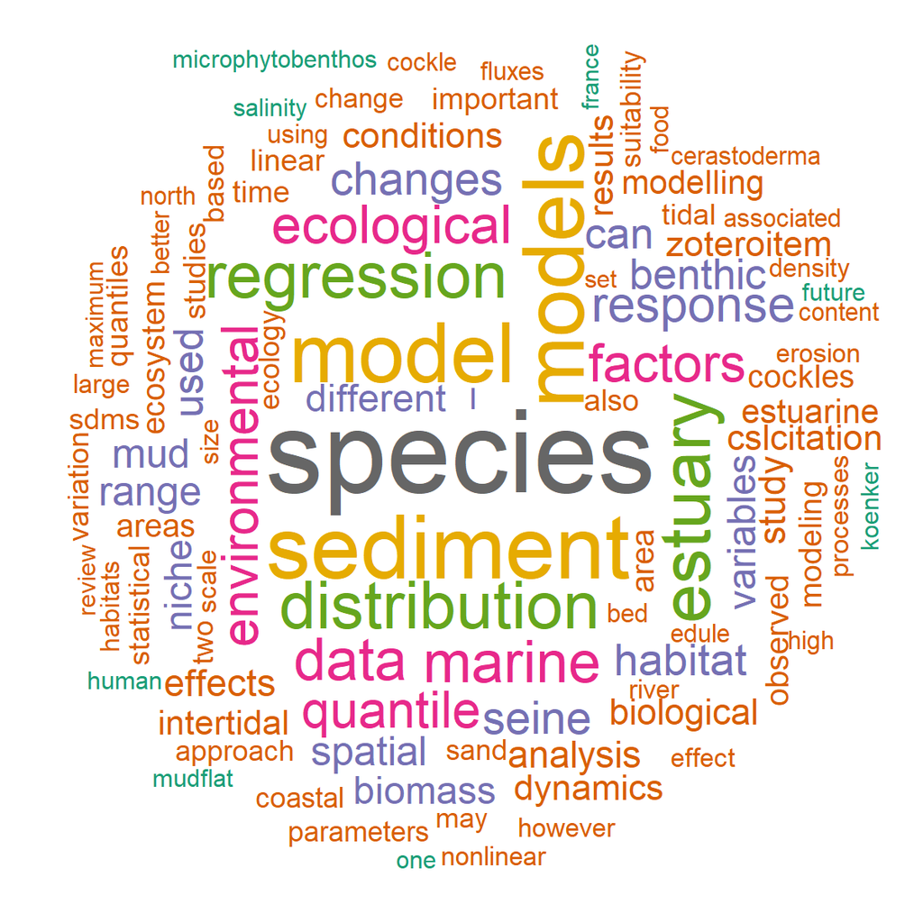